# Week 3 Lab sheet with answers

Yiling Huo

2024-05-14

*All data in the exercises are simulated fake data.*

# Before the exercises: Object types in R

- Numerics: numbers. `a <- 0.1`, `a <- 5`.
- Characters: strings. `a <- "hello world"`, `a <- "3"`.
- **Vectors**: a list of items that are of the same type. `a <- c()`. For example, `fruits <- c("banana", "apple", "orange")`, fruits is a vector of strings.
- **Factors**: used to categorise data. `a <- factor()`. For example, `music_genre <- factor(c("Jazz", "Rock", "Classic", "Classic", "Pop", "Jazz", "Rock", "Jazz"))`, music_genre is a factor with 4 levels Jazz, Rock, Classic, and Pop (duplicate values are ignored). It’s good practice to convert categorical independent variables to factors before running statistical analysis.
- Lists: a collection of data which is ordered and changeable. `a <- list()`. For example, `edibles <- list(c("banana", "apple", "orange"), c("tomato", "potato", "spinach"), c("rice", "bread", "noodle"))`, edibles is a list of vectors.
- Matrices: two-dimensional object with rows and columns. `a <- matrix()`. For example, `thismatrix <- matrix(c(1,2,3,4,5,6), nrow = 3, ncol = 2)`, thismatrix is a matrix with 2 columns and 3 rows.
- Arrays: compared to matrices, arrays can have one, two , or more than two dimensions. `a <- array()`. For example, `thisarray <- array(1:24)`, thisarray is a one-dimensional array.
- **Data frames**: data displayed in a table-like format.`a <- data.frame()`. For example, `df <- data.frame (Training = c("Strength", "Stamina", "Other"), Pulse = c(100, 150, 120), Duration = c(60, 30, 45))`, df is a data frame with columns Training, Pulse, and Duration, with three rows of data.

# Excercise 1: IQ test

Suppose I want to know whether UCL students’ IQs are significantly different from the average (100). I randomly picked 20 students at UCL and asked them to do an IQ test.

Fun fact: IQ tests are specifically designed such that the average person would receive the score 100.

Here are their scores: 117 125 116 113 102 122 123 93 99 129 132 94 85 92 101 83 119 119 101 97 (mean = 108.1, s.d.=15.05).

1. Decide which test statistics to use.

   This wasn’t officially part of the lecture but it should be the one sample t-test. The idea is very simple: is the mean of a group of values significantly different from *a specific number*?
   - We have one group of data and we want to compare its mean to a specific value. This should be a one-sample t-test.
2. Decide which object type to save the collection of this data and save the data as an object. Choose between strings, vectors, and lists. Hint: We might not have talked about this in class. Try finding out the answer in the [R documentation](https://www.rdocumentation.org/packages/stats/versions/3.6.2/topics/t.test) (important skill to learn!).
   - Vectors, as those are valid arguments for the `t.test()` function.

```r
data = c(117, 125, 116, 113, 102, 122, 123, 93, 99, 129, 132, 94, 85, 92, 101, 83, 119, 119, 101, 97)
```

3. Calculate the mean and the standard deviation (in R).

```r
mean(data)
```

```
## [1] 108.1
```

```r
sd(data)
```

```
## [1] 15.05394
```

4. Check whether the data are normally distributed.

```r
shapiro.test(data)
```

```
##
##  Shapiro-Wilk normality test
##
## data:  data
## W = 0.94113, p-value = 0.2518
```

5. Run the one sample t-test. Hint: `t.test(data, mu = 100)`.

```r
t.test(data, mu=100)
```

```
##
##  One Sample t-test
##
## data:  data
## t = 2.4063, df = 19, p-value = 0.02646
## alternative hypothesis: true mean is not equal to 100
## 95 percent confidence interval:
##  101.0545 115.1455
## sample estimates:
## mean of x
##     108.1
```

6. Are UCL students’ IQs significantly different from the average?
   - Looks like so.
7. Report your findings in a short paragraph.

A one-sample t-test was run to determine whether the mean IQ scores for students at university A (n=20) was different from the average IQ (µ=100). Sampled IQ scores were normally distributed as assessed by Shapiro-Wilk’s test (p= 0.25) and there were no outliers in the data. The group of 20 students were found to have a significantly higher IQ (M=108.1, s.d.=15.05) than the average, t(19) = 2.4, p < 0.03.

# Exercise 2: Word frequency in two types of writings

I’m interested in whether the frequency of the word ‘museum’ differ between humanities journal papers and blog articles on similar topics. I randomly accessed 10 corpora of humanities journals papers, and calculated the count of the word ‘museum’ per million words in each corpus. And then I did the same with humanities blog articles.

Frequencies of ‘museum’ in each journal paper corpus (count per million): 76 67 66 72 74 64 72 70 74 78

Frequencies of ‘museum’ in each blog article corpus (count per million): 66 63 68 68 60 67 58 70 67 66

1. Decide which test to use.
   - Independent samples t-test: there are two groups, the journal paper group, and the blog article group. We have different ‘participants’ for different groups (jounal paper corpora vs. blog article corpora).
2. Make a data frame with the data:

```r
values <- c(76, 67, 66, 72, 74, 64, 72, 70, 74, 78, 66, 63, 68, 68, 60, 67, 58, 70, 67, 66)
groups <- rep(c('journal', 'blog'), each=10)
data_2 <- data.frame(groups, values)
# print the data to take a look
data_2
```

```
##     groups values
## 1  journal     76
## 2  journal     67
## 3  journal     66
## 4  journal     72
## 5  journal     74
## 6  journal     64
## 7  journal     72
## 8  journal     70
## 9  journal     74
## 10 journal     78
## 11    blog     66
## 12    blog     63
## 13    blog     68
## 14    blog     68
## 15    blog     60
## 16    blog     67
## 17    blog     58
## 18    blog     70
## 19    blog     67
## 20    blog     66
```

3. Visualise your data using `boxplot()`.

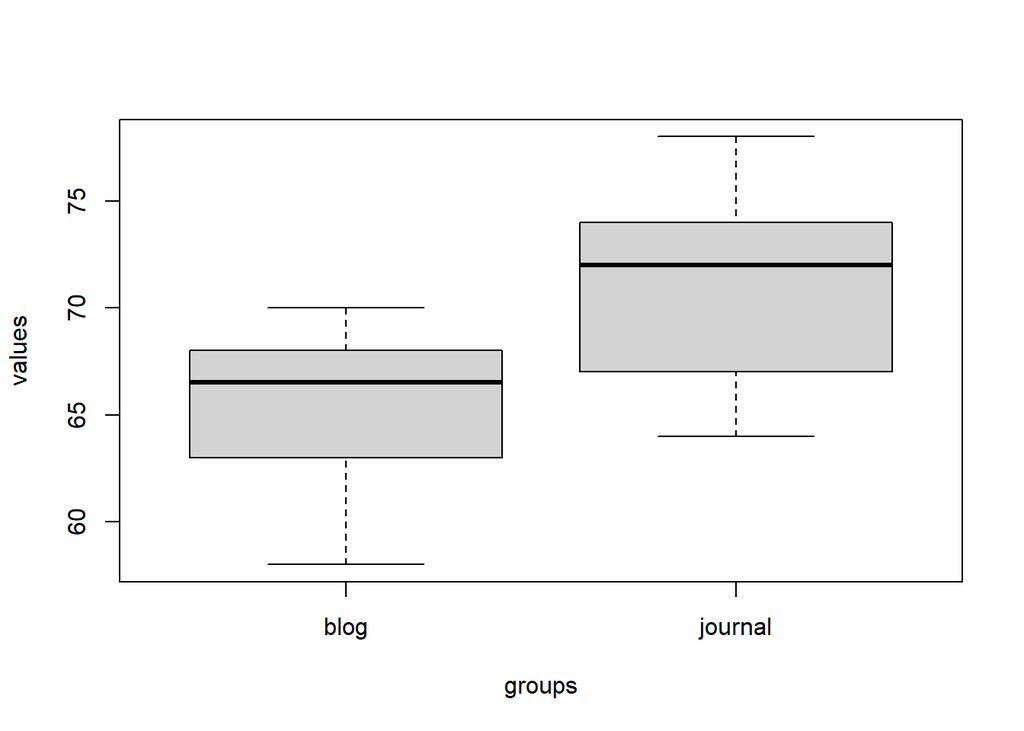

```r
boxplot(values ~ groups, data = data_2)
```

4. Get the descriptive statistics (means and standard deviations) using `describeBy()` from the `psych` package.

```r
library(psych)
describeBy(values ~ groups, data = data_2, digits = 2)
```

```
##
##  Descriptive statistics by group
## groups: blog
##        vars  n mean  sd median trimmed  mad min max range  skew kurtosis  se
## values    1 10 65.3 3.8   66.5   65.62 2.22  58  70    12 -0.72    -0.96 1.2
## ------------------------------------------------------------
## groups: journal
##        vars  n mean   sd median trimmed  mad min max range  skew kurtosis   se
## values    1 10 71.3 4.52     72   71.38 4.45  64  78    14 -0.19    -1.43 1.43
```

5. Check whether your data meet the assumptions of your chosen statistical test.

```r
# Check for normality
tapply(data_2$values, data_2$groups, shapiro.test)
```

```
## $blog
##
##  Shapiro-Wilk normality test
##
## data:  X[[i]]
## W = 0.88842, p-value = 0.1627
##
##
## $journal
##
##  Shapiro-Wilk normality test
##
## data:  X[[i]]
## W = 0.96276, p-value = 0.8168
```

```r
# Check for homogeneity of variance
library(car)
leveneTest(values ~ factor(groups), data = data_2)
```

```
## Levene's Test for Homogeneity of Variance (center = median)
##       Df F value Pr(>F)
## group  1  0.4171 0.5265
##       18
```

6. Run the test.

```r
t.test(values ~ groups, data=data_2, var.equal=TRUE)
```

```
##
##  Two Sample t-test
##
## data:  values by groups
## t = -3.2112, df = 18, p-value = 0.004842
## alternative hypothesis: true difference in means between group blog and group journal is not equal to 0
## 95 percent confidence interval:
##  -9.925471 -2.074529
## sample estimates:
##    mean in group blog mean in group journal
##                  65.3                  71.3
```

7. Is there a significant difference between the frequency of ‘musuem’ in journal papers and blog articles?
   - Looks like so.
8. Report your findings in a short paragraph.

Independent samples t-test showed that the frequency of the word ‘museum’ was significantly lower in blog articles in humanities than journal papers in humanities (t(18)=-3.21, p=0.004). Data was randomly collected from 10 blog article corpora and 10 journal paper corpora (blog: M=65.3, s.d.=3.8; journal:M=71.3, s.d.=4.52).

# Exercise 3: Grammaticallity judgment

An experimental syntactician conducted an experiment on what’s called the that-trace phenomenon. 30 participants were presented with sentences such as (1) and (2). They were asked to judge the sentences’ grammaticallity on a 7 point scale (1 = totally ungrammatical; 7 = totally grammatical).

1. Who do you think that will hire Mary? (‘that’ condition)
2. Who do you think will hire Mary? (‘no that’ condition)

At the end, the researcher calculated the average score given to that sentences and no-that sentences for each participants (such that each person has a score in the ‘that’ condition and one score in the ‘no-that’ condition). The researcher now want to know whether there is a significant difference between the grammaticallity of ‘that’ sentences and ‘no-that’ sentences.

1. Download the data [Here](https://yiling-huo.github.io/plinstat-handouts/data/that-trace.csv).
2. Read the data into a data frame by running `data <- read.csv('that-trace.csv', header = TRUE)`.

```r
data_3 <- read.csv('that-trace.csv', header = TRUE)
# print the data to take a look
data_3
```

```
##    participant condition average_judgement
## 1            1   no_that              5.31
## 2            2   no_that              6.90
## 3            3   no_that              5.22
## 4            4   no_that              6.05
## 5            5   no_that              5.23
## 6            6   no_that              6.68
## 7            7   no_that              6.63
## 8            8   no_that              6.24
## 9            9   no_that              6.45
## 10          10   no_that              6.32
## 11          11   no_that              5.61
## 12          12   no_that              6.88
## 13          13   no_that              6.40
## 14          14   no_that              6.59
```

[output cut: 46 more lines]

3. Visualise the data using a boxplot and get the descriptive statistics.

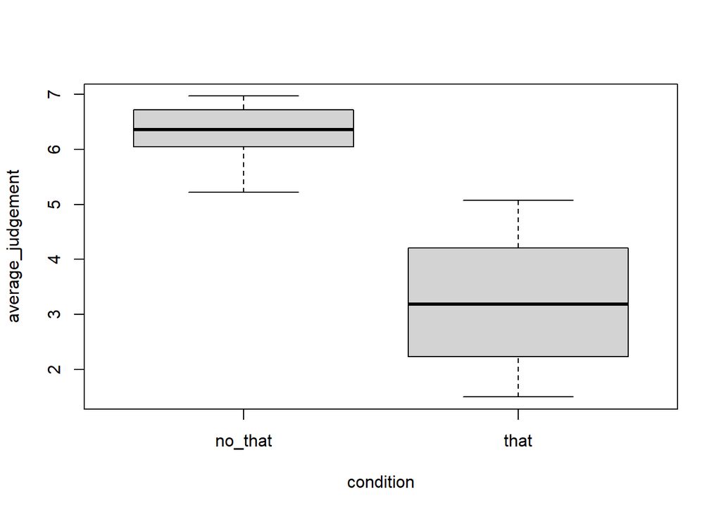

```r
boxplot(average_judgement ~ condition, data = data_3)
```

```r
library(psych)
describeBy(average_judgement ~ condition, data = data_3, digits = 2)
```

```
##
##  Descriptive statistics by group
## condition: no_that
##                   vars  n mean   sd median trimmed mad  min  max range  skew
## average_judgement    1 30  6.3 0.51   6.36    6.36 0.5 5.22 6.97  1.75 -0.67
##                   kurtosis   se
## average_judgement    -0.59 0.09
## ------------------------------------------------------------
## condition: that
##                   vars  n mean   sd median trimmed  mad min  max range  skew
## average_judgement    1 30 3.27 1.04   3.18    3.27 1.42 1.5 5.08  3.58 -0.03
##                   kurtosis   se
## average_judgement    -1.23 0.19
```

4. Take a look at the data and decide which statistical test to use to answer the research questions.
   - Paired samples t-test: We have two conditions, ‘that’ and ‘no_that’. The same participants were in the two conditions.
5. Check whether the data meet the assumptions of your chosen test.

```r
# 1. Normality (of difference)
data_3_dif <- with(data_3, average_judgement[condition == 'no_that'] - average_judgement[condition == 'that'])
shapiro.test(data_3_dif)
```

```
##
##  Shapiro-Wilk normality test
##
## data:  data_3_dif
## W = 0.96302, p-value = 0.3692
```

6. Run the test. Is there a significant difference?

```r
t.test(average_judgement ~ condition, data = data_3, paired = TRUE)
```

```
##
##  Paired t-test
##
## data:  average_judgement by condition
## t = 14.754, df = 29, p-value = 5.143e-15
## alternative hypothesis: true mean difference is not equal to 0
## 95 percent confidence interval:
##  2.611120 3.451547
## sample estimates:
## mean difference
##        3.031333
```

7. Report your findings in a short paragraph.

Paired samples t-test showed that sentences such as (2) were judged significantly higher in acceptability than sentences such as (1) (t(29)=14.75, p<0.001) (that: M=3.27, s.d.=1.04; no that: M=6.3, s.d.=0.51).

# Exercise 4: Effect of interlocutor language distance on perceived phonetic convergence

During conversation, people often change the way they speak to sound more alike each other, this phenomenon is called phonetic convergence.

A researcher recorded some spontaneous conversations in English. These conversations were grouped by interlocutor language distance: Close (native Southern accent - native Southern accent); Intermediate (native Southern accent - native Northern accent); and Far (L2 English - L2 English (of different L1’s)). Each group had 15 conversations. All conversations were from different speakers.

The example is adapted from Kim, M., Horton, W. S., & Bradlow, A. R. (2011). Phonetic convergence in spontaneous conversations as a function of interlocutor language distance. Note that data used in this exercise are randomly generated fake data and conclusions may differ from the real experiment.

Phonetic convergence is evaluated based on change in speach similarity: how close is speaker A’s speech to speaker B’s speech, at the end of the conversation compared with at the beginning of the conversation. In other words, **the data are the convergence scores: similarity scores at the end - similarity scores at the beginning.** The researcher is interested in whether interlocutor language distance affects phonetic convergence. In other words, the researcher wants to compare the mean convergence scores and see whether they differ from one another.

1. Download the data [Here](https://yiling-huo.github.io/plinstat-handouts/data/interlocutor.csv).
2. Read the data into a data frame by running `data <- read.csv('interlocutor.csv', header = TRUE)`.

```r
data_4 <- read.csv('interlocutor.csv', header = TRUE)
data_4$conversation <- as.factor(data_4$conversation)
```

3. Visualise the data using a boxplot and get descriptive statistics.

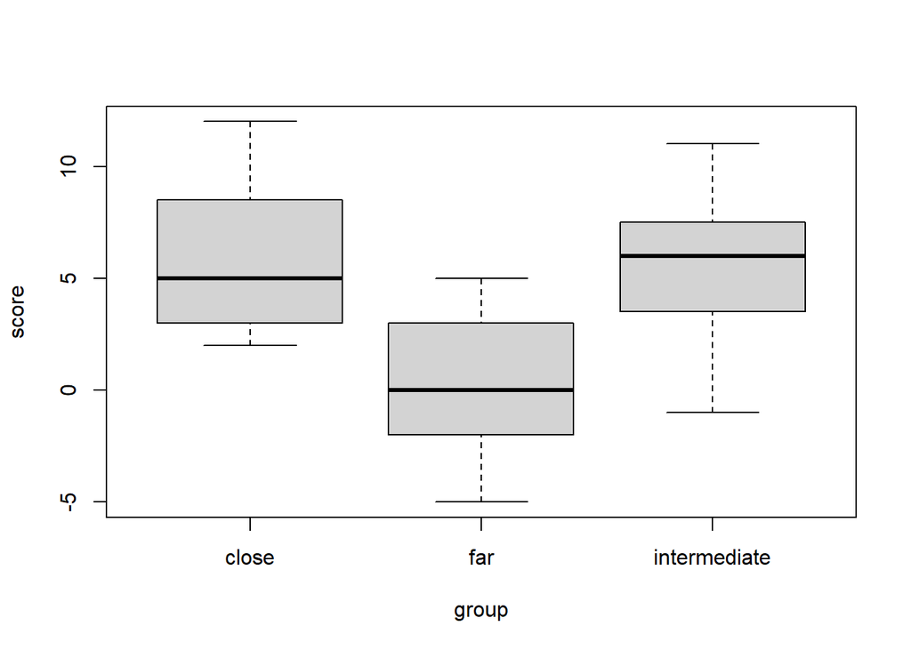

```r
# visualise our data
boxplot(score ~ group, data = data_4)
```

```r
# get some descriptive statistics
library(psych)
describeBy(score ~ group, data = data_4)
```

```
##
##  Descriptive statistics by group
## group: close
##       vars  n mean   sd median trimmed  mad min max range skew kurtosis   se
## score    1 15 5.93 3.35      5    5.77 2.97   2  12    10 0.53    -1.32 0.86
## ------------------------------------------------------------
## group: far
##       vars  n mean  sd median trimmed  mad min max range  skew kurtosis   se
## score    1 15 0.27 3.2      0    0.31 2.97  -5   5    10 -0.15    -1.31 0.83
## ------------------------------------------------------------
## group: intermediate
##       vars  n mean  sd median trimmed  mad min max range  skew kurtosis   se
## score    1 15  5.4 3.6      6    5.46 2.97  -1  11    12 -0.18    -1.07 0.93
```

4. Take a look at the data and decide which statistical test to use.
   - One-way between-subjects ANOVA: We have one factor: interlocutor language distance. The factor has three levels (we have three groups): close, intermediate, and far.
5. Check whether the data meet the assumptions and run the test.

```r
# Run the one-way between-subject ANOVA
data_4_result <- aov(score ~ group, data = data_4)
# take a look at our results using the summary() function
summary(data_4_result)
```

```
##             Df Sum Sq Mean Sq F value   Pr(>F)
## group        2  293.7  146.87   12.81 4.53e-05 ***
## Residuals   42  481.5   11.46
## ---
## Signif. codes:  0 '***' 0.001 '**' 0.01 '*' 0.05 '.' 0.1 ' ' 1
```

```r
# Check for normality (of residuals)
# using Shapiro-Wilk test
data_4_residuals <- residuals(object = data_4_result)
shapiro.test(data_4_residuals)
```

```
##
##  Shapiro-Wilk normality test
##
## data:  data_4_residuals
## W = 0.9695, p-value = 0.2777
```

```r
# Check for homogeneity of variance
library(car)
leveneTest(score ~ group, data = data_4)
```

```
## Levene's Test for Homogeneity of Variance (center = median)
##       Df F value Pr(>F)
## group  2  0.0053 0.9947
##       42
```

```r
# Finally, run pair-wise t-tests with Bonferroni correction as post-hocs.
pairwise.t.test(data_4$score, data_4$group, p.adjust.method = "bonferroni")
```

```
##
##  Pairwise comparisons using t tests with pooled SD
##
## data:  data_4$score and data_4$group
##
##              close   far
## far          0.00012 -
## intermediate 1.00000 0.00047
##
## P value adjustment method: bonferroni
```

6. Does interlocutor language distance affect phonetic convergence? Report your findings in a short paragraph.

The results of one-way analysis of variance (ANOVA) with one between-subject factor Interlocutor Language Distance (ILD) (Close vs. Intermediate vs. Far) indicate a significant main effect of ILD (F(2, 42)=12.81, p<0.001). Follow-up pairwise t-tests using Bonferroni correction method revealed that the main effect was due to significant difference of the far distance group from the others (both p’s<0.001), while there was no significant difference between the Close group and the Intermediate group (Close: M=5.93, s.d.=3.35; Intermediate: M=5.4, s.d.=3.6; Far: M=0.27, s.d.=3.2).